# Approximating Quantities and Probabilities from The Wright-Fisher Model

```r
library(tidyverse)
```

# Introduction

The Wright-Fisher model provides a way of modelling the random inheritance of genes from one generation to the next. In its simplest incarnation, the population size is constant each generation: $N$ haploid individuals. Each individual can thus be represented by a single gene copy. The gene copies in generation $t+1$ are obtained by sampling *with replacement* from amongst the gene copies in generation $t$.

Let us assume we are concerned with a single locus at which there are two different alleles, $A$ and $a$. And we let the random variable $X_t$ record the number of $A$ alleles (out of $N$) in the population at generation $t$. Initially (at $t=0$) there are $x_0$ copies of the $A$ allele. Under the Wright-Fisher model’s sampling with replacement from the previous generation, we have a binomial distribution with $N$ draws, each with a success probability $p$ of $x_t/N$
$$X_{t+1} \sim \mathrm{Binomial}(N; x_t/N)~~~~,~~~~t = 1, 2, \ldots$$

Given this setup, we can write a function to simulate $R$ different replicates of the Wright-Fisher model, starting from an initial allele frequency of $X_0$, and proceeding $T$ generations until $X_T$ is obtained. I have provided such a function that returns the results for all the replicate simulations in a tibble with three columns:

- **rep** the number of the replicate run
- **t** the number of the generation
- **x** the number of copies of the $A$ allele at generation $t$ in from replicate `rep`.

If you are not familiar with a `tibble` it is similar to a data frame, but it forms the basis for many operations in the “tidyverse” way of using R, made popular by Hadley Wickham. The tidyverse provides a unified way of handling many different genres of data using ideas that are foundational to relational databases. There should be at least a few individuals in each break-out group that are familiar with the tidyverse that can help those that are not experienced with it. If you have not run across the tidyverse before, then it would be worth reading up on it. An excellent book that covers many aspects of the tidyverse is available at https://r4ds.had.co.nz/.

Here is the function:

```r
#' simulate R reps of a Wright-Fisher model of size N haploids for T generations from an initial allele count of X0
#'
#' Default values for the simulatiions are given as shown.
#'
#' @param R number of replicate simulations to do
#' @param N number of haploids, each generation, in the population
#' @param T number of generations of sampling to simulate
#' @param X0 the initial number of A alleles.  Must be <= N
WF <- function(
  R = 1000,
  N = 100,
  T = 20,
  X0 = 30
) {
  stopifnot(X0 <= N)

  lapply(1:R, function(r) { # cycling over the different replicates
    # initialize a vector to store the results
    x <- rep(NA, T)

    # get X1
    x[1] <- rbinom(n = 1, size = N, prob = X0 / N)

    # cycle over the remaining generations (for loop is slow but makes
    # it easier to read what is going on)
    for (t in 2:T) {
      x[t] <- rbinom(n = 1, size = N, prob = x[t - 1] / N)
    }

    # return a tibble of results
    tibble(
      rep = r,
      t = 1:T,
      x = x
    )
  }) %>%
    bind_rows()   # at the end, bind them all into a single tibble
}
```

It is not super fast, but it works well enough. It also returns every $X_t$ for every replicate run of the Wright-Fisher model. So we can estimate a variety of quantities with the output, using Monte Carlo.

## Examples

To recreate the histogram of $x_{10}$ values in the lecture you can do:

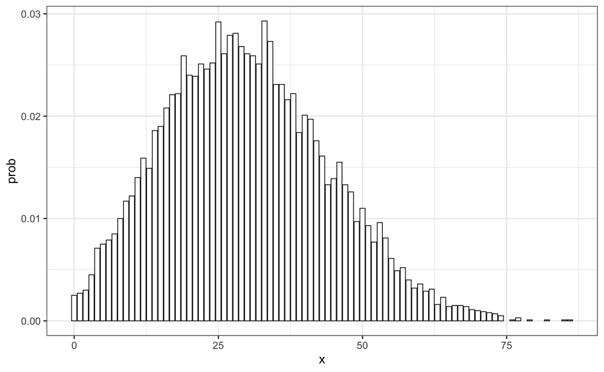

```r
set.seed(5)
ex1 <- WF(
  R = 1e4,
  N = 100,
  T = 12,
  X0 = 30
  )

# then count up the different x_10 values
counts10 <- ex1 %>%
  filter(t == 10) %>%
  count(x) %>%
  mutate(prob = n / sum(n))

# and, plot it
g <- ggplot(counts10, aes(x = x, y = prob)) +
  geom_col(fill = "white", colour = "black", size = 0.3) +
  theme_bw()

g
```

Or to look at the allele frequencies over each generation from 1 to 12, we could do:

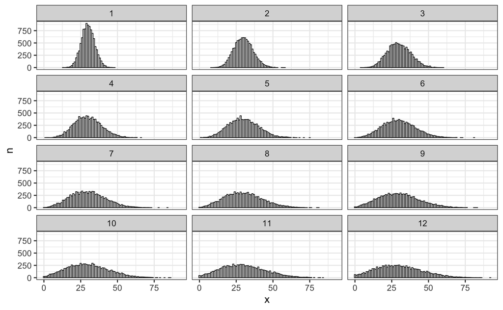

```r
counts_all <- ex1 %>%
  count(t, x)

# and, plot it
ggplot(counts_all, aes(x = x, y = n)) +
  geom_col(fill = "white", colour = "black", size = 0.3) +
  theme_bw() +
  facet_wrap(~ t, ncol = 3)
```

## Exercises

```r
S <- WF(
  R = 1e4,
  N = 100,
  T = 20,
  X0 = 30
  )
S %>%
  group_by(t) %>%
  summarise(meanX_t = mean(x))
```

| t | meanX_t |
| --- | --- |
| 1 | 30.0175 |
| 2 | 30.0228 |
| 3 | 30.0562 |
| 4 | 30.0795 |
| 5 | 30.1299 |
| 6 | 30.1444 |
| 7 | 30.1635 |
| 8 | 30.2184 |
| 9 | 30.2228 |
| 10 | 30.1933 |

[output cut: 10 more lines]

```r
S %>%
  group_by(t) %>%
  summarise(meanH_t = mean( (x * (100 - x)) / (100 * 99)))
```

| t | meanH_t |
| --- | --- |
| 1 | 0.2100844 |
| 2 | 0.2080359 |
| 3 | 0.2061833 |
| 4 | 0.2041601 |
| 5 | 0.2022231 |
| 6 | 0.2002243 |
| 7 | 0.1981114 |
| 8 | 0.1964445 |
| 9 | 0.1945483 |
| 10 | 0.1925649 |

[output cut: 10 more lines]

3. Simulate 1,000 replicates of a haploid population of size 100 for 1,000 generations, with $X_0 = 30$, and, from the output, approximate (via histogram) the distribution of time until fixation (i.e., the first generation $t$, at which $X_t = 0$ or $X_t = 100$.)

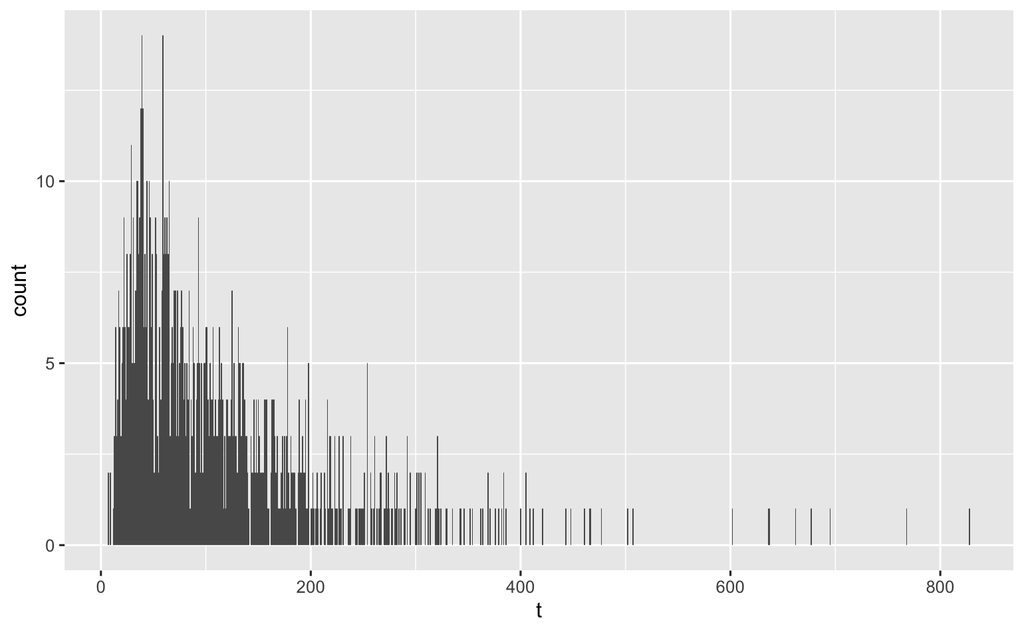

```r
S2 <- WF(
  R = 1000,
  N = 100,
  T = 1000,
  X0 = 30
)

fix_times <- S2 %>%
  arrange(rep, t) %>% # just to ensure things are sorted correctly
  group_by(rep) %>%
  filter(x == 0 | x == 100) %>% # only keep the time steps after the allele is fixed
  slice(1) # take the first of those times in which the allele is fixed

ggplot(fix_times, aes(x = t)) +
  geom_histogram(binwidth = 1)
```

When doing MCMC you might often work like this: a large number of variable states get written to disk or stored in a variable, and then after the fact you can use them in Monte Carlo.